# Supervised Learning - Foundations Project: ReCell

### Analysing the best features

1. Generally speaking, iOS is a little more consistent in how it works, while Android is much more customizable, (example : Android lets you install apps from third-party sources, while iOS doesn’t.)

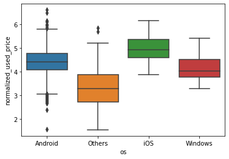

```python
sns.boxplot(data=df, x='os', y='normalized_used_price');
plt.show()
```

- Median value of the `normalized_used_price` is the highest for devices with iOS(5 euros), followed by Android(4.5 euros).
- The boxplot shows some outliers too.

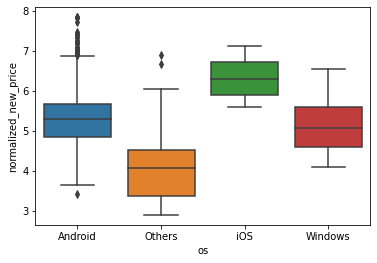

```python
sns.boxplot(data=df, x='os', y='normalized_new_price');
plt.show()
```

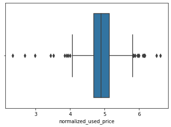

```python
storage_df = df[(df['ram']>=4) & (df['int_memory']>=64)]
sns.boxplot(data=storage_df, x='normalized_used_price');
plt.show()
```

- Median value of the `normalized_used_price` for devices with at least 4GB of RAM and 64GB of internal memory is about 4.9 euros.
- The boxplot shows some outliers.

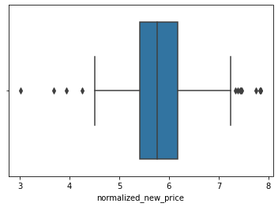

```python
sns.boxplot(data=storage_df, x='normalized_new_price');
plt.show()
```

- Median value of the `normalized_new_price` for devices with at least 4GB of RAM and 64GB of internal memory is about 5.8 euros.
- The boxplot shows some outliers.
1. Newer phones tend to have better cameras than older models.

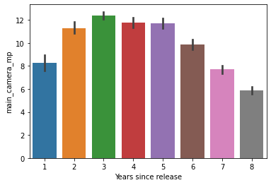

```python
sns.barplot(data=df, x=2021-df['release_year'], y='main_camera_mp');
plt.xlabel('Years since release');
plt.show()
```

- The plot shows an increase in the resolution of the rear camera every year, but the trend has a negative incline from 2019.

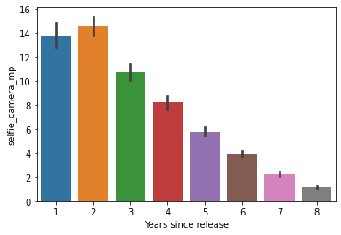

```python
sns.barplot(data=df, x=2021-df['release_year'], y='selfie_camera_mp');
plt.xlabel('Years since release');
plt.show()
```

- There is a rise in the resolution of the front camera with each passing year, but this trend has gone down in 2020.
1. Every 10 years or so, a new generation of network comes out. Right now, we’re in the midst of the deployment of 5G. If connecting to different types of networks is desired, we need to check that the device supports the different networks for the carrier.

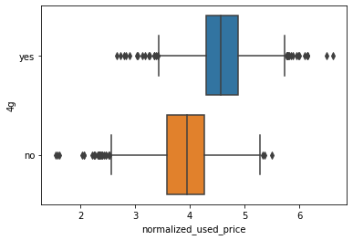

```python
sns.boxplot(data=df, x='normalized_used_price', y='4g');
plt.show()
```

```python
df[df['4g']=='yes']['normalized_used_price'].median()
```

```
4.573266636975083
```

```python
df[df['4g']=='no']['normalized_used_price'].median()
```

```
3.949896657856228
```

- Median value of `normalized_used_price` for devices supporting 4g is about 4.6 euros and for the ones not supporting 4g is about 3.95 euros.

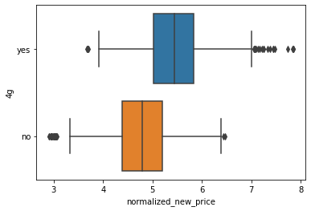

```python
sns.boxplot(data=df, x='normalized_new_price', y='4g');
plt.show()
```

```python
df[df['4g']=='yes']['normalized_new_price'].median()
```

```
5.440337626568466
```

```python
df[df['4g']=='no']['normalized_new_price'].median()
```

```
4.79015486020153
```

- Median value of `normalized_new_price` for devices supporting 4g is about 5.44 euros and for the ones not supporting 4g is about 4.79 euros.

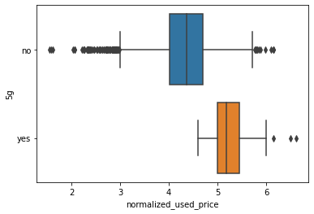

```python
sns.boxplot(data=df, x='normalized_used_price', y='5g');
plt.show()
```

```python
df[df['5g']=='yes']['normalized_used_price'].median()
```

```
5.178265330934775
```

```python
df[df['5g']=='no']['normalized_used_price'].median()
```

```
4.372291887653269
```

- Median value of `normalized_used_price` for devices supporting 5g is about 5.17 euros and for the ones not supporting 5g is about 4.37 euros.

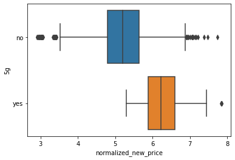

```python
sns.boxplot(data=df, x='normalized_new_price', y='5g');
plt.show()
```

```python
df[df['5g']=='yes']['normalized_new_price'].median()
```

```
6.214177983876705
```

```python
df[df['5g']=='no']['normalized_new_price'].median()
```

```
5.196007741588178
```

- Median value of `normalized_new_price` for devices supporting 5g is about 6.2 euros and for the ones not supporting 5g is about 5.2 euros.
1. Analysing years since release vs `normalized_used_price`

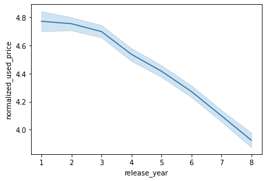

```python
sns.lineplot(data=df, x=2021-df['release_year'], y='normalized_used_price');
plt.show()
```

- Newer devices tend to have higher `normalized_used_price` than older devices.
1. Analysing years since release vs `normalized_new_price`

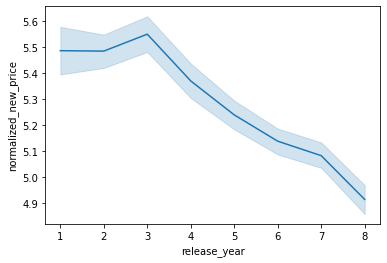

```python
sns.lineplot(data=df, x=2021-df['release_year'], y='normalized_new_price');
plt.show()
```

- `normalized_new_price` has increased for new devices. However, this trend has gone down in the last couple of years.

Qn.7. Which attributes are highly correlated with the normalized price of a used device?

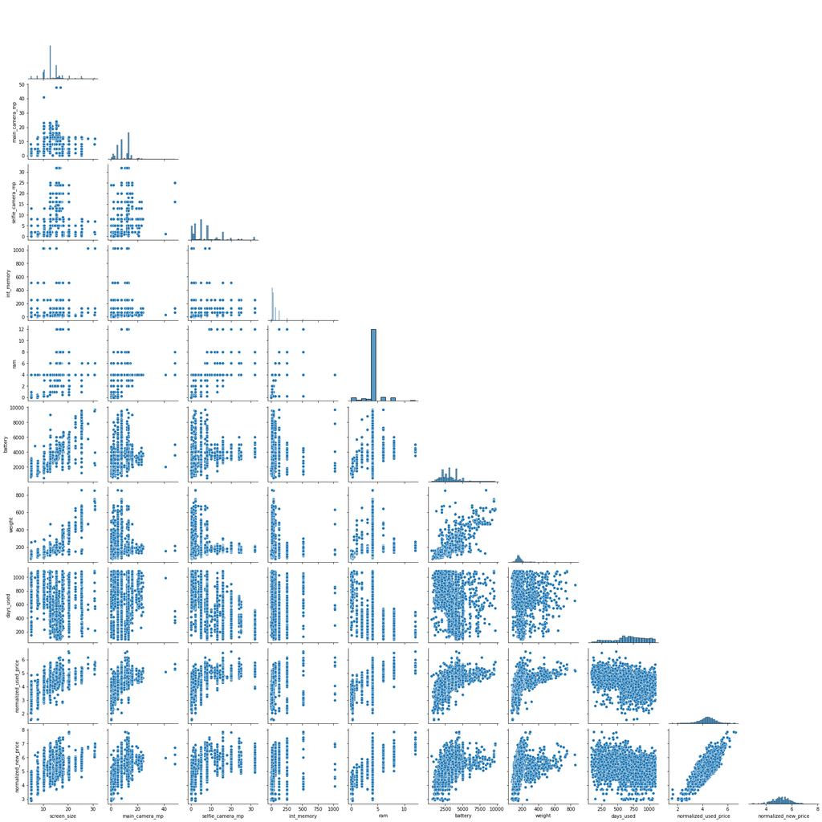

```python
col_list = df.select_dtypes(include=np.number).columns.tolist()
col_list.remove('release_year')
sns.pairplot(data=df[col_list], corner=True);
plt.show()
```

- From the pair plot, we see that `normalized_new_price` is highly correlated with the normalized price of a used device.

## Data Preprocessing

```python
# creating a copy of dataset again
df1 = df.copy()
```

- Missing value treatment

```python
df1.isna().sum() #displays the number of missing values in each column of the dataframe
```

```
brand_name                 0
os                         0
screen_size                0
4g                         0
5g                         0
main_camera_mp           179
selfie_camera_mp           2
int_memory                 4
ram                        4
battery                    6
weight                     7
release_year               0
days_used                  0
normalized_used_price      0
normalized_new_price       0
dtype: int64
```

- 179 values from `main_camera_mp`, 2 from `selfie_camera_mp`, 4 each from `int_memory` and `ram`, 6 from `battery` and 7 from `weight` are missing.
- These columns contain numerical values. Hence, we impute the missing values with their corresponding medians.

```python
df1['main_camera_mp'] = df1['main_camera_mp'].fillna(df1['main_camera_mp'].median())
```

```python
df1.isnull().sum() #rechecking the number of missing values in each column after imputing
```

```
brand_name               0
os                       0
screen_size              0
4g                       0
5g                       0
main_camera_mp           0
selfie_camera_mp         2
int_memory               4
ram                      4
battery                  6
weight                   7
release_year             0
days_used                0
normalized_used_price    0
normalized_new_price     0
dtype: int64
```

```python
df1['selfie_camera_mp'] = df1['selfie_camera_mp'].fillna(df1['selfie_camera_mp'].median())
```

```python
df1.isnull().sum() #rechecking the number of missing values in each column after imputing
```

```
brand_name               0
os                       0
screen_size              0
4g                       0
5g                       0
main_camera_mp           0
selfie_camera_mp         0
int_memory               4
ram                      4
battery                  6
weight                   7
release_year             0
days_used                0
normalized_used_price    0
normalized_new_price     0
dtype: int64
```

```python
df1['int_memory'] = df1['int_memory'].fillna(df1['int_memory'].median())
```

```python
df1.isnull().sum() #rechecking the number of missing values in each column after imputing
```

```
brand_name               0
os                       0
screen_size              0
4g                       0
5g                       0
main_camera_mp           0
selfie_camera_mp         0
int_memory               0
ram                      4
battery                  6
weight                   7
release_year             0
days_used                0
normalized_used_price    0
normalized_new_price     0
dtype: int64
```

```python
df1['ram'] = df1['ram'].fillna(df1['ram'].median())
```

```python
df1.isnull().sum() #rechecking the number of missing values in each column after imputing
```

```
brand_name               0
os                       0
screen_size              0
4g                       0
5g                       0
main_camera_mp           0
selfie_camera_mp         0
int_memory               0
ram                      0
battery                  6
weight                   7
release_year             0
days_used                0
normalized_used_price    0
normalized_new_price     0
dtype: int64
```

```python
df1['battery'] = df1['battery'].fillna(df1['battery'].median())
```

```python
df1.isnull().sum() #rechecking the number of missing values in each column after imputing
```

```
brand_name               0
os                       0
screen_size              0
4g                       0
5g                       0
main_camera_mp           0
selfie_camera_mp         0
int_memory               0
ram                      0
battery                  0
weight                   7
release_year             0
days_used                0
normalized_used_price    0
normalized_new_price     0
dtype: int64
```

```python
df1['weight'] = df1['weight'].fillna(df1['weight'].median())
```

```python
df1.isnull().sum() #rechecking the number of missing values in each column after imputing
```

```
brand_name               0
os                       0
screen_size              0
4g                       0
5g                       0
main_camera_mp           0
selfie_camera_mp         0
int_memory               0
ram                      0
battery                  0
weight                   0
release_year             0
days_used                0
normalized_used_price    0
normalized_new_price     0
dtype: int64
```

- Feature engineering (if needed)

Changing `release_year` to `years_since_release`, calculated using the formula: years_since_release = 2021 - release_year

```python
df1['years_since_release'] = 2021 - df1['release_year']
df1.drop(['release_year'], axis=1, inplace=True)
df1.head()
```

|  | brand_name | os | screen_size | 4g | 5g | main_camera_mp | selfie_camera_mp | int_memory | ram | battery | weight | days_used | normalized_used_price | normalized_new_price | years_since_release |
| --- | --- | --- | --- | --- | --- | --- | --- | --- | --- | --- | --- | --- | --- | --- | --- |
| 0 | Honor | Android | 14.50 | yes | no | 13.0 | 5.0 | 64.0 | 3.0 | 3020.0 | 146.0 | 127 | 4.307572 | 4.715100 | 1 |
| 1 | Honor | Android | 17.30 | yes | yes | 13.0 | 16.0 | 128.0 | 8.0 | 4300.0 | 213.0 | 325 | 5.162097 | 5.519018 | 1 |
| 2 | Honor | Android | 16.69 | yes | yes | 13.0 | 8.0 | 128.0 | 8.0 | 4200.0 | 213.0 | 162 | 5.111084 | 5.884631 | 1 |
| 3 | Honor | Android | 25.50 | yes | yes | 13.0 | 8.0 | 64.0 | 6.0 | 7250.0 | 480.0 | 345 | 5.135387 | 5.630961 | 1 |
| 4 | Honor | Android | 15.32 | yes | no | 13.0 | 8.0 | 64.0 | 3.0 | 5000.0 | 185.0 | 293 | 4.389995 | 4.947837 | 1 |

- Outlier detection and treatment (if needed)

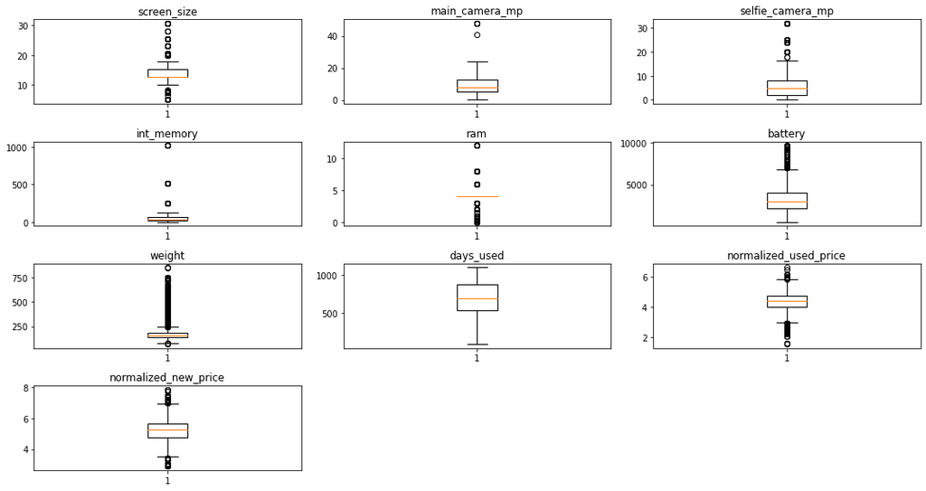

```python
numeric_cols = ['screen_size', 'main_camera_mp', 'selfie_camera_mp',
                'int_memory', 'ram', 'battery', 'weight', 'days_used',
                'normalized_used_price', 'normalized_new_price']
plt.figure(figsize=[15,8])

for i, variable in enumerate(numeric_cols):
  plt.subplot(4,3,i+1)
  plt.boxplot(df1[variable], whis=1.5);
  plt.tight_layout()
  plt.title(variable)
```

```python
# checking the number of values and percentage of data which is outside of IQR for int_memory
Q1 = df1['int_memory'].quantile(0.25)
Q3 = df1['int_memory'].quantile(0.75)
IQR = Q3-Q1
lower_whisker = Q1 - (1.5*IQR)
upper_whisker = Q3 + (1.5*IQR)
print(df1[(df1['int_memory']<lower_whisker) | (df1['int_memory']>upper_whisker)].shape[0])
perc = df1[(df1['int_memory']<lower_whisker) | (df1['int_memory']>upper_whisker)].shape[0]/df1.shape[0]
print(perc)
```

```
138
0.039953676896352056
```

```python
# checking the number of values and percentage of data which is outside of IQR for battery
Q1 = df1['battery'].quantile(0.25)
Q3 = df1['battery'].quantile(0.75)
IQR = Q3-Q1
lower_whisker = Q1 - (1.5*IQR)
upper_whisker = Q3 + (1.5*IQR)
print(df1[(df1['battery']<lower_whisker) | (df1['battery']>upper_whisker)].shape[0])
perc = df1[(df1['battery']<lower_whisker) | (df1['battery']>upper_whisker)].shape[0]/df1.shape[0]
print(perc)
```

```
77
0.022292993630573247
```

```python
# checking the number of values and percentage of data which is outside of IQR for weight
Q1 = df1['weight'].quantile(0.25)
Q3 = df1['weight'].quantile(0.75)
IQR = Q3-Q1
lower_whisker = Q1 - (1.5*IQR)
upper_whisker = Q3 + (1.5*IQR)
print(df1[(df1['weight']<lower_whisker) | (df1['weight']>upper_whisker)].shape[0])
perc = df1[(df1['weight']<lower_whisker) | (df1['weight']>upper_whisker)].shape[0]/df1.shape[0]
print(perc)
```

```
368
0.10654313839027214
```

```python
# checking the number of values and percentage of data which is outside of IQR for normalized_used_price
Q1 = df1['normalized_used_price'].quantile(0.25)
Q3 = df1['normalized_used_price'].quantile(0.75)
IQR = Q3-Q1
lower_whisker = Q1 - (1.5*IQR)
upper_whisker = Q3 + (1.5*IQR)
print(df1[(df1['normalized_used_price']<lower_whisker) | (df1['normalized_used_price']>upper_whisker)].shape[0])
perc = df1[(df1['normalized_used_price']<lower_whisker) | (df1['normalized_used_price']>upper_whisker)].shape[0]/df1.shape[0]
print(perc)
```

```
85
0.02460914881297047
```

```python
# checking the number of values and percentage of data which is outside of IQR for normalized_new_price
Q1 = df1['normalized_new_price'].quantile(0.25)
Q3 = df1['normalized_new_price'].quantile(0.75)
IQR = Q3-Q1
lower_whisker = Q1 - (1.5*IQR)
upper_whisker = Q3 + (1.5*IQR)
print(df1[(df1['normalized_new_price']<lower_whisker) | (df1['normalized_new_price']>upper_whisker)].shape[0])
perc = df1[(df1['normalized_new_price']<lower_whisker) | (df1['normalized_new_price']>upper_whisker)].shape[0]/df1.shape[0]
print(perc)
```

```
66
0.01910828025477707
```

- Flooring/capping the outliers can cause high variation in dataset.
- It's better not to treat any outliers in this case.
- Preparing data for modeling

Creating dummy variables

```python
# creating dummy variables for 4g
df1 = pd.get_dummies(df1, columns=['4g'], drop_first=True)
df1.head()
```

|  | brand_name | os | screen_size | 5g | main_camera_mp | selfie_camera_mp | int_memory | ram | battery | weight | days_used | normalized_used_price | normalized_new_price | years_since_release | 4g_yes |
| --- | --- | --- | --- | --- | --- | --- | --- | --- | --- | --- | --- | --- | --- | --- | --- |
| 0 | Honor | Android | 14.50 | no | 13.0 | 5.0 | 64.0 | 3.0 | 3020.0 | 146.0 | 127 | 4.307572 | 4.715100 | 1 | 1 |
| 1 | Honor | Android | 17.30 | yes | 13.0 | 16.0 | 128.0 | 8.0 | 4300.0 | 213.0 | 325 | 5.162097 | 5.519018 | 1 | 1 |
| 2 | Honor | Android | 16.69 | yes | 13.0 | 8.0 | 128.0 | 8.0 | 4200.0 | 213.0 | 162 | 5.111084 | 5.884631 | 1 | 1 |
| 3 | Honor | Android | 25.50 | yes | 13.0 | 8.0 | 64.0 | 6.0 | 7250.0 | 480.0 | 345 | 5.135387 | 5.630961 | 1 | 1 |
| 4 | Honor | Android | 15.32 | no | 13.0 | 8.0 | 64.0 | 3.0 | 5000.0 | 185.0 | 293 | 4.389995 | 4.947837 | 1 | 1 |

```python
# creating dummy variables for 5g
df1 = pd.get_dummies(df1, columns=['5g'], drop_first=True)
df1.head()
```

|  | brand_name | os | screen_size | main_camera_mp | selfie_camera_mp | int_memory | ram | battery | weight | days_used | normalized_used_price | normalized_new_price | years_since_release | 4g_yes | 5g_yes |
| --- | --- | --- | --- | --- | --- | --- | --- | --- | --- | --- | --- | --- | --- | --- | --- |
| 0 | Honor | Android | 14.50 | 13.0 | 5.0 | 64.0 | 3.0 | 3020.0 | 146.0 | 127 | 4.307572 | 4.715100 | 1 | 1 | 0 |
| 1 | Honor | Android | 17.30 | 13.0 | 16.0 | 128.0 | 8.0 | 4300.0 | 213.0 | 325 | 5.162097 | 5.519018 | 1 | 1 | 1 |
| 2 | Honor | Android | 16.69 | 13.0 | 8.0 | 128.0 | 8.0 | 4200.0 | 213.0 | 162 | 5.111084 | 5.884631 | 1 | 1 | 1 |
| 3 | Honor | Android | 25.50 | 13.0 | 8.0 | 64.0 | 6.0 | 7250.0 | 480.0 | 345 | 5.135387 | 5.630961 | 1 | 1 | 1 |
| 4 | Honor | Android | 15.32 | 13.0 | 8.0 | 64.0 | 3.0 | 5000.0 | 185.0 | 293 | 4.389995 | 4.947837 | 1 | 1 | 0 |

```python
# creating dummy variables for os
df1 = pd.get_dummies(df1, columns=['os'], drop_first=True)
df1.head()
```

|  | brand_name | screen_size | main_camera_mp | selfie_camera_mp | int_memory | ram | battery | weight | days_used | normalized_used_price | normalized_new_price | years_since_release | 4g_yes | 5g_yes | os_Others | os_Windows | os_iOS |
| --- | --- | --- | --- | --- | --- | --- | --- | --- | --- | --- | --- | --- | --- | --- | --- | --- | --- |
| 0 | Honor | 14.50 | 13.0 | 5.0 | 64.0 | 3.0 | 3020.0 | 146.0 | 127 | 4.307572 | 4.715100 | 1 | 1 | 0 | 0 | 0 | 0 |
| 1 | Honor | 17.30 | 13.0 | 16.0 | 128.0 | 8.0 | 4300.0 | 213.0 | 325 | 5.162097 | 5.519018 | 1 | 1 | 1 | 0 | 0 | 0 |
| 2 | Honor | 16.69 | 13.0 | 8.0 | 128.0 | 8.0 | 4200.0 | 213.0 | 162 | 5.111084 | 5.884631 | 1 | 1 | 1 | 0 | 0 | 0 |
| 3 | Honor | 25.50 | 13.0 | 8.0 | 64.0 | 6.0 | 7250.0 | 480.0 | 345 | 5.135387 | 5.630961 | 1 | 1 | 1 | 0 | 0 | 0 |
| 4 | Honor | 15.32 | 13.0 | 8.0 | 64.0 | 3.0 | 5000.0 | 185.0 | 293 | 4.389995 | 4.947837 | 1 | 1 | 0 | 0 | 0 | 0 |

- Any other preprocessing steps (if needed)

Categorize the devices into low price, medium price and high price, based on the `normalized_new_price`

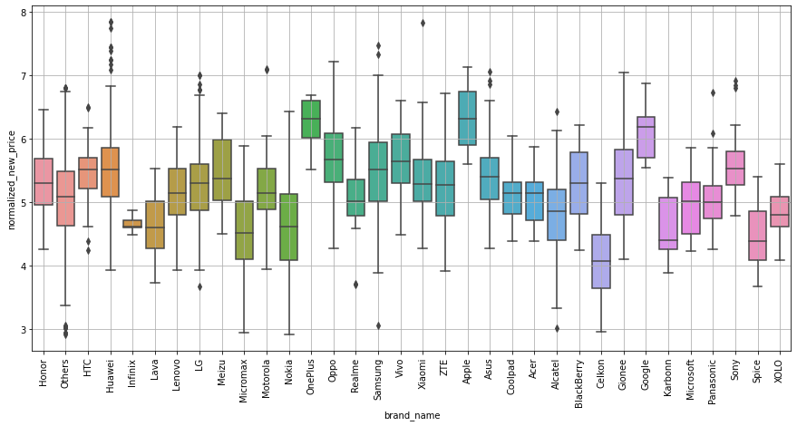

```python
plt.figure(figsize=[15,7])
plt.xticks(rotation=90)
sns.boxplot(data=df1, x='brand_name', y='normalized_new_price');
plt.grid()
plt.show()
```

```python
df_median = df1.groupby(['brand_name'])['normalized_new_price'].median().reset_index()
df1 = pd.merge(df1, df_median, on='brand_name', how='outer')
df1.head()
```

|  | brand_name | screen_size | main_camera_mp | selfie_camera_mp | int_memory | ram | battery | weight | days_used | normalized_used_price | normalized_new_price_x | years_since_release | 4g_yes | 5g_yes | os_Others | os_Windows | os_iOS | normalized_new_price_y |
| --- | --- | --- | --- | --- | --- | --- | --- | --- | --- | --- | --- | --- | --- | --- | --- | --- | --- | --- |
| 0 | Honor | 14.50 | 13.0 | 5.0 | 64.0 | 3.0 | 3020.0 | 146.0 | 127 | 4.307572 | 4.715100 | 1 | 1 | 0 | 0 | 0 | 0 | 5.301959 |
| 1 | Honor | 17.30 | 13.0 | 16.0 | 128.0 | 8.0 | 4300.0 | 213.0 | 325 | 5.162097 | 5.519018 | 1 | 1 | 1 | 0 | 0 | 0 | 5.301959 |
| 2 | Honor | 16.69 | 13.0 | 8.0 | 128.0 | 8.0 | 4200.0 | 213.0 | 162 | 5.111084 | 5.884631 | 1 | 1 | 1 | 0 | 0 | 0 | 5.301959 |
| 3 | Honor | 25.50 | 13.0 | 8.0 | 64.0 | 6.0 | 7250.0 | 480.0 | 345 | 5.135387 | 5.630961 | 1 | 1 | 1 | 0 | 0 | 0 | 5.301959 |
| 4 | Honor | 15.32 | 13.0 | 8.0 | 64.0 | 3.0 | 5000.0 | 185.0 | 293 | 4.389995 | 4.947837 | 1 | 1 | 0 | 0 | 0 | 0 | 5.301959 |

```python
df1.tail()
```

|  | brand_name | screen_size | main_camera_mp | selfie_camera_mp | int_memory | ram | battery | weight | days_used | normalized_used_price | normalized_new_price_x | years_since_release | 4g_yes | 5g_yes | os_Others | os_Windows | os_iOS | normalized_new_price_y |
| --- | --- | --- | --- | --- | --- | --- | --- | --- | --- | --- | --- | --- | --- | --- | --- | --- | --- | --- |
| 3449 | XOLO | 10.24 | 5.0 | 0.30 | 16.0 | 4.0 | 2000.0 | 150.0 | 739 | 3.782597 | 4.939640 | 8 | 0 | 0 | 0 | 0 | 0 | 4.795212 |
| 3450 | XOLO | 7.75 | 5.0 | 0.65 | 16.0 | 4.0 | 1500.0 | 132.0 | 1088 | 3.516607 | 4.608465 | 8 | 0 | 0 | 0 | 0 | 0 | 4.795212 |
| 3451 | XOLO | 12.70 | 8.0 | 1.20 | 16.0 | 4.0 | 2100.0 | 171.1 | 974 | 4.028739 | 5.006828 | 8 | 0 | 0 | 0 | 0 | 0 | 4.795212 |
| 3452 | XOLO | 10.29 | 8.0 | 1.00 | 16.0 | 4.0 | 2100.0 | 143.5 | 571 | 3.779405 | 4.869916 | 8 | 0 | 0 | 0 | 0 | 0 | 4.795212 |
| 3453 | XOLO | 10.29 | 5.0 | 0.30 | 16.0 | 4.0 | 2400.0 | 151.3 | 824 | 3.543854 | 4.606769 | 8 | 0 | 0 | 0 | 0 | 0 | 4.795212 |

```python
conditions = [(df1['normalized_new_price_y']<5),
              ((df1['normalized_new_price_y']>=5) & (df1['normalized_new_price_y']<6)),
              (df1['normalized_new_price_y']>=6)]
values = ['low', 'medium', 'high']
df1['price_range']= np.select(conditions, values)
df1.head()
```

|  | brand_name | screen_size | main_camera_mp | selfie_camera_mp | int_memory | ram | battery | weight | days_used | normalized_used_price | normalized_new_price_x | years_since_release | 4g_yes | 5g_yes | os_Others | os_Windows | os_iOS | normalized_new_price_y | price_range |
| --- | --- | --- | --- | --- | --- | --- | --- | --- | --- | --- | --- | --- | --- | --- | --- | --- | --- | --- | --- |
| 0 | Honor | 14.50 | 13.0 | 5.0 | 64.0 | 3.0 | 3020.0 | 146.0 | 127 | 4.307572 | 4.715100 | 1 | 1 | 0 | 0 | 0 | 0 | 5.301959 | medium |
| 1 | Honor | 17.30 | 13.0 | 16.0 | 128.0 | 8.0 | 4300.0 | 213.0 | 325 | 5.162097 | 5.519018 | 1 | 1 | 1 | 0 | 0 | 0 | 5.301959 | medium |
| 2 | Honor | 16.69 | 13.0 | 8.0 | 128.0 | 8.0 | 4200.0 | 213.0 | 162 | 5.111084 | 5.884631 | 1 | 1 | 1 | 0 | 0 | 0 | 5.301959 | medium |
| 3 | Honor | 25.50 | 13.0 | 8.0 | 64.0 | 6.0 | 7250.0 | 480.0 | 345 | 5.135387 | 5.630961 | 1 | 1 | 1 | 0 | 0 | 0 | 5.301959 | medium |
| 4 | Honor | 15.32 | 13.0 | 8.0 | 64.0 | 3.0 | 5000.0 | 185.0 | 293 | 4.389995 | 4.947837 | 1 | 1 | 0 | 0 | 0 | 0 | 5.301959 | medium |

```python
df1.tail()
```

|  | brand_name | screen_size | main_camera_mp | selfie_camera_mp | int_memory | ram | battery | weight | days_used | normalized_used_price | normalized_new_price_x | years_since_release | 4g_yes | 5g_yes | os_Others | os_Windows | os_iOS | normalized_new_price_y | price_range |
| --- | --- | --- | --- | --- | --- | --- | --- | --- | --- | --- | --- | --- | --- | --- | --- | --- | --- | --- | --- |
| 3449 | XOLO | 10.24 | 5.0 | 0.30 | 16.0 | 4.0 | 2000.0 | 150.0 | 739 | 3.782597 | 4.939640 | 8 | 0 | 0 | 0 | 0 | 0 | 4.795212 | low |
| 3450 | XOLO | 7.75 | 5.0 | 0.65 | 16.0 | 4.0 | 1500.0 | 132.0 | 1088 | 3.516607 | 4.608465 | 8 | 0 | 0 | 0 | 0 | 0 | 4.795212 | low |
| 3451 | XOLO | 12.70 | 8.0 | 1.20 | 16.0 | 4.0 | 2100.0 | 171.1 | 974 | 4.028739 | 5.006828 | 8 | 0 | 0 | 0 | 0 | 0 | 4.795212 | low |
| 3452 | XOLO | 10.29 | 8.0 | 1.00 | 16.0 | 4.0 | 2100.0 | 143.5 | 571 | 3.779405 | 4.869916 | 8 | 0 | 0 | 0 | 0 | 0 | 4.795212 | low |
| 3453 | XOLO | 10.29 | 5.0 | 0.30 | 16.0 | 4.0 | 2400.0 | 151.3 | 824 | 3.543854 | 4.606769 | 8 | 0 | 0 | 0 | 0 | 0 | 4.795212 | low |

```python
df1 = pd.get_dummies(df1, columns=['price_range'], drop_first=True)
df1.head()
```

|  | brand_name | screen_size | main_camera_mp | selfie_camera_mp | int_memory | ram | battery | weight | days_used | normalized_used_price | normalized_new_price_x | years_since_release | 4g_yes | 5g_yes | os_Others | os_Windows | os_iOS | normalized_new_price_y | price_range_low | price_range_medium |
| --- | --- | --- | --- | --- | --- | --- | --- | --- | --- | --- | --- | --- | --- | --- | --- | --- | --- | --- | --- | --- |
| 0 | Honor | 14.50 | 13.0 | 5.0 | 64.0 | 3.0 | 3020.0 | 146.0 | 127 | 4.307572 | 4.715100 | 1 | 1 | 0 | 0 | 0 | 0 | 5.301959 | 0 | 1 |
| 1 | Honor | 17.30 | 13.0 | 16.0 | 128.0 | 8.0 | 4300.0 | 213.0 | 325 | 5.162097 | 5.519018 | 1 | 1 | 1 | 0 | 0 | 0 | 5.301959 | 0 | 1 |
| 2 | Honor | 16.69 | 13.0 | 8.0 | 128.0 | 8.0 | 4200.0 | 213.0 | 162 | 5.111084 | 5.884631 | 1 | 1 | 1 | 0 | 0 | 0 | 5.301959 | 0 | 1 |
| 3 | Honor | 25.50 | 13.0 | 8.0 | 64.0 | 6.0 | 7250.0 | 480.0 | 345 | 5.135387 | 5.630961 | 1 | 1 | 1 | 0 | 0 | 0 | 5.301959 | 0 | 1 |
| 4 | Honor | 15.32 | 13.0 | 8.0 | 64.0 | 3.0 | 5000.0 | 185.0 | 293 | 4.389995 | 4.947837 | 1 | 1 | 0 | 0 | 0 | 0 | 5.301959 | 0 | 1 |

```python
df1.drop(['brand_name'], axis=1, inplace=True)
```

```python
df1.head()
```

|  | screen_size | main_camera_mp | selfie_camera_mp | int_memory | ram | battery | weight | days_used | normalized_used_price | normalized_new_price_x | years_since_release | 4g_yes | 5g_yes | os_Others | os_Windows | os_iOS | normalized_new_price_y | price_range_low | price_range_medium |
| --- | --- | --- | --- | --- | --- | --- | --- | --- | --- | --- | --- | --- | --- | --- | --- | --- | --- | --- | --- |
| 0 | 14.50 | 13.0 | 5.0 | 64.0 | 3.0 | 3020.0 | 146.0 | 127 | 4.307572 | 4.715100 | 1 | 1 | 0 | 0 | 0 | 0 | 5.301959 | 0 | 1 |
| 1 | 17.30 | 13.0 | 16.0 | 128.0 | 8.0 | 4300.0 | 213.0 | 325 | 5.162097 | 5.519018 | 1 | 1 | 1 | 0 | 0 | 0 | 5.301959 | 0 | 1 |
| 2 | 16.69 | 13.0 | 8.0 | 128.0 | 8.0 | 4200.0 | 213.0 | 162 | 5.111084 | 5.884631 | 1 | 1 | 1 | 0 | 0 | 0 | 5.301959 | 0 | 1 |
| 3 | 25.50 | 13.0 | 8.0 | 64.0 | 6.0 | 7250.0 | 480.0 | 345 | 5.135387 | 5.630961 | 1 | 1 | 1 | 0 | 0 | 0 | 5.301959 | 0 | 1 |
| 4 | 15.32 | 13.0 | 8.0 | 64.0 | 3.0 | 5000.0 | 185.0 | 293 | 4.389995 | 4.947837 | 1 | 1 | 0 | 0 | 0 | 0 | 5.301959 | 0 | 1 |

Dropping the columns `normalized_new_price_x` and `normalized_new_price_y` as the columns `price_range_low` and `price_range_medium` contribute the same information

```python
df1.drop(['normalized_new_price_x'], axis=1, inplace=True)
```

```python
df1.drop(['normalized_new_price_y'], axis=1, inplace=True)
```

```python
df1.info()
```

```
<class 'pandas.core.frame.DataFrame'>
Int64Index: 3454 entries, 0 to 3453
Data columns (total 17 columns):
 #   Column                 Non-Null Count  Dtype
---  ------                 --------------  -----
 0   screen_size            3454 non-null   float64
 1   main_camera_mp         3454 non-null   float64
 2   selfie_camera_mp       3454 non-null   float64
 3   int_memory             3454 non-null   float64
 4   ram                    3454 non-null   float64
 5   battery                3454 non-null   float64
 6   weight                 3454 non-null   float64
 7   days_used              3454 non-null   int64
 8   normalized_used_price  3454 non-null   float64
 9   years_since_release    3454 non-null   int64
 10  4g_yes                 3454 non-null   uint8
 11  5g_yes                 3454 non-null   uint8
 12  os_Others              3454 non-null   uint8
 13  os_Windows             3454 non-null   uint8
 14  os_iOS                 3454 non-null   uint8
 15  price_range_low        3454 non-null   uint8
 16  price_range_medium     3454 non-null   uint8
dtypes: float64(8), int64(2), uint8(7)
memory usage: 320.4 KB
```

## EDA

- It is a good idea to explore the data once again after manipulating it.

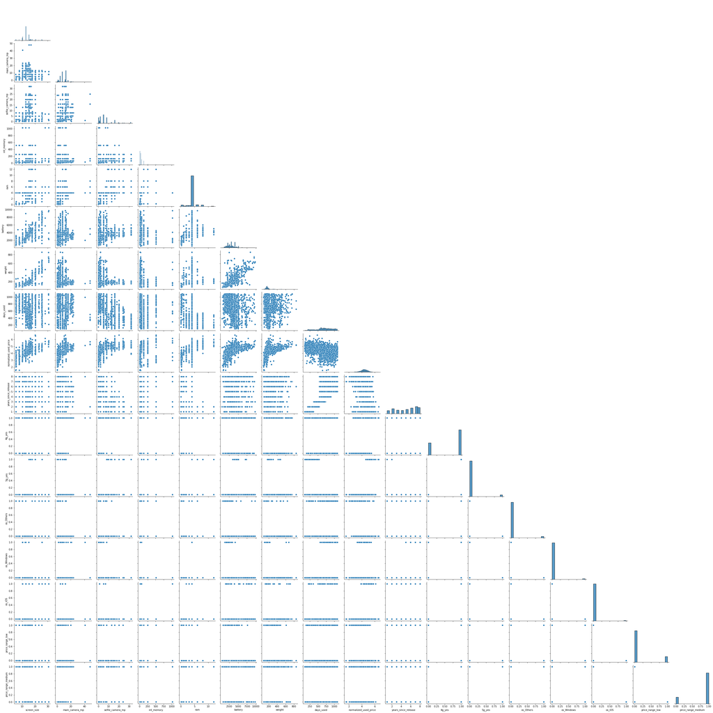

```python
sns.pairplot(data=df1, corner=True);
plt.show()
```

## Model Building - Linear Regression

```python
#splitting the data into dependent and independent variables
X = df1.drop(['normalized_used_price'], axis=1) #independent variables
y = df1['normalized_used_price'] # dependent variable
```

```python
# adding intercept to data
X = sm.add_constant(X)
```

```python
#splitting data in the ratio of 70:30 for train and test sets
X_train, X_test, y_train, y_test = train_test_split(
    X, y, test_size=0.30, random_state=1
)
```

```python
X_train.shape
```

```
(2417, 17)
```

```python
X_test.shape
```

```
(1037, 17)
```

```python
X_train.head()
```

|  | const | screen_size | main_camera_mp | selfie_camera_mp | int_memory | ram | battery | weight | days_used | years_since_release | 4g_yes | 5g_yes | os_Others | os_Windows | os_iOS | price_range_low | price_range_medium |
| --- | --- | --- | --- | --- | --- | --- | --- | --- | --- | --- | --- | --- | --- | --- | --- | --- | --- |
| 3026 | 1.0 | 12.70 | 5.0 | 0.3 | 16.0 | 4.0 | 3000.0 | 162.00 | 753 | 7 | 1 | 0 | 0 | 0 | 0 | 1 | 0 |
| 1525 | 1.0 | 12.70 | 8.0 | 2.0 | 32.0 | 4.0 | 2000.0 | 138.00 | 1054 | 7 | 0 | 0 | 0 | 0 | 0 | 1 | 0 |
| 1128 | 1.0 | 12.70 | 13.0 | 5.0 | 16.0 | 4.0 | 4000.0 | 149.00 | 652 | 6 | 1 | 0 | 0 | 0 | 0 | 0 | 1 |
| 3003 | 1.0 | 12.70 | 5.0 | 2.0 | 16.0 | 4.0 | 2820.0 | 142.95 | 732 | 6 | 1 | 0 | 0 | 0 | 0 | 1 | 0 |
| 2907 | 1.0 | 12.83 | 8.0 | 8.0 | 32.0 | 4.0 | 4000.0 | 165.00 | 942 | 6 | 1 | 0 | 0 | 0 | 0 | 0 | 1 |

```python
#making the linear model using statsmodels OLS and printing the model summary
olsmod = sm.OLS(y_train, X_train)
olsres = olsmod.fit()
print(olsres.summary())
```

```
                              OLS Regression Results
=================================================================================
Dep. Variable:     normalized_used_price   R-squared:                       0.748
Model:                               OLS   Adj. R-squared:                  0.747
Method:                    Least Squares   F-statistic:                     446.1
Date:                   Fri, 05 Aug 2022   Prob (F-statistic):               0.00
Time:                           22:11:17   Log-Likelihood:                -460.82
No. Observations:                   2417   AIC:                             955.6
Df Residuals:                       2400   BIC:                             1054.
Df Model:                             16
Covariance Type:               nonrobust
=======================================================================================
                          coef    std err          t      P>|t|      [0.025      0.975]
---------------------------------------------------------------------------------------
const                   2.8682      0.081     35.582      0.000       2.710       3.026
screen_size             0.0410      0.004      9.972      0.000       0.033       0.049
main_camera_mp          0.0372      0.002     23.040      0.000       0.034       0.040
selfie_camera_mp        0.0226      0.001     16.245      0.000       0.020       0.025
int_memory              0.0003    7.7e-05      4.500      0.000       0.000       0.000
ram                     0.0769      0.006     12.043      0.000       0.064       0.089
battery              6.629e-06   9.26e-06      0.716      0.474   -1.15e-05    2.48e-05
weight                  0.0009      0.000      5.815      0.000       0.001       0.001
days_used            1.153e-05   3.76e-05      0.307      0.759   -6.22e-05    8.53e-05
years_since_release     0.0181      0.005      3.366      0.001       0.008       0.029
4g_yes                  0.1865      0.019      9.905      0.000       0.150       0.223
5g_yes                  0.1093      0.040      2.727      0.006       0.031       0.188
os_Others              -0.1199      0.037     -3.232      0.001      -0.193      -0.047
os_Windows              0.0760      0.043      1.764      0.078      -0.008       0.160
os_iOS                  0.0164      0.079      0.206      0.837      -0.139       0.172
price_range_low        -0.3965      0.059     -6.683      0.000      -0.513      -0.280
price_range_medium     -0.3083      0.057     -5.438      0.000      -0.419      -0.197
==============================================================================
Omnibus:                      176.314   Durbin-Watson:                   1.936
Prob(Omnibus):                  0.000   Jarque-Bera (JB):              916.569
Skew:                          -0.011   Prob(JB):                    9.32e-200
Kurtosis:                       6.017   Cond. No.                     7.07e+04
==============================================================================

Warnings:
[1] Standard Errors assume that the covariance matrix of the errors is correctly specified.
[2] The condition number is large, 7.07e+04. This might indicate that there are
strong multicollinearity or other numerical problems.
```

- The R-squared value says that our model can explain 74.8% of the variance in the training data.
- If multicollinearity exists in the linear model, then the coefficients and p-values suggested by the model becomes unreliable.
- We'll test multicollinearity using variance inflation factor, VIF.

```python
# let's check the VIF of the predictors
from statsmodels.stats.outliers_influence import variance_inflation_factor

vif_series1 = pd.Series([variance_inflation_factor(X_train.values, i) for i in range(X_train.shape[1])], index=X_train.columns)
print("VIF values: \n\n{}\n".format(vif_series1))
```

```
VIF values:

const                  181.902814
screen_size              6.900337
main_camera_mp           1.650845
selfie_camera_mp         2.484069
int_memory               1.173354
ram                      1.939876
battery                  4.076276
weight                   6.017934
days_used                2.417525
years_since_release      4.200555
4g_yes                   2.147828
5g_yes                   1.697942
os_Others                1.424995
os_Windows               1.030671
os_iOS                   2.021371
price_range_low         12.916897
price_range_medium      13.182587
dtype: float64
```

- Variables `price_range_low` and `price_range_medium` have VIF>10, which are signs of high multicollinearity.
- Variables `screen_size` and `weight` have VIF>5, which are signs of moderate multicollinearity.
- We'll remove/drop multicollinear columns one by one and observe the effect on our predictive model.

```python
#Dropping 'price_range_medium' to check its effect on R2 and R2_adj
X_train2 = X_train.drop(['price_range_medium'], axis=1)
olsmod1 = sm.OLS(y_train, X_train2)
olsres1 = olsmod1.fit()
print("R2 : ", olsres1.rsquared)
print("R2_adj : ", olsres1.rsquared_adj)
print("Difference in R2_adj : ", round(olsres.rsquared_adj-olsres1.rsquared_adj,3))
```

```
R2 :  0.7452438477640739
R2_adj :  0.7436522849637661
Difference in R2_adj :  0.003
```

On dropping `price_range_medium`, the R2_adj decreased by 0.003.

```python
#Dropping 'price_range_low' to check its effect on R2 and R2_adj
X_train3 = X_train.drop(['price_range_low'], axis=1)
olsmod2 = sm.OLS(y_train, X_train3)
olsres2 = olsmod2.fit()
print("R2 : ", olsres2.rsquared)
print("R2_adj : ", olsres2.rsquared_adj)
print("Difference in R2_adj : ", round(olsres.rsquared_adj-olsres2.rsquared_adj,3))
```

```
R2 :  0.7436610896212367
R2_adj :  0.7420596387025855
Difference in R2_adj :  0.005
```

On dropping `price_range_low`, the R2_adj decreased by 0.005.

```python
#Dropping 'screen_size' to check its effect on R2 and R2_adj
X_train4 = X_train.drop(['screen_size'], axis=1)
olsmod3 = sm.OLS(y_train, X_train4)
olsres3 = olsmod3.fit()
print("R2 : ", olsres3.rsquared)
print("R2_adj : ", olsres3.rsquared_adj)
print("Difference in R2_adj : ", round(olsres.rsquared_adj-olsres3.rsquared_adj,3))
```

```
R2 :  0.7379164083765103
R2_adj :  0.7362790681539562
Difference in R2_adj :  0.01
```

On dropping `screen_size`, there is a sharp decrease in R2_adj by 0.01.

```python
#Dropping 'weight' to check its effect on R2 and R2_adj
X_train5 = X_train.drop(['weight'], axis=1)
olsmod4 = sm.OLS(y_train, X_train5)
olsres4 = olsmod4.fit()
print("R2 : ", olsres4.rsquared)
print("R2_adj : ", olsres4.rsquared_adj)
print("Difference in R2_adj : ", round(olsres.rsquared_adj-olsres4.rsquared_adj,3))
```

```
R2 :  0.744798156742275
R2_adj :  0.7432038095332514
Difference in R2_adj :  0.003
```

On dropping `weight`, the R2_adj decreased by 0.003.

We'll start by dropping `price_range_medium` and check VIF

```python
X_train = X_train.drop(['price_range_medium'], axis=1)
```

```python
olsmod5 = sm.OLS(y_train, X_train)
olsres5 = olsmod5.fit()
```

```python
vif_series2 = pd.Series([variance_inflation_factor(X_train.values, i) for i in range(X_train.shape[1])], index=X_train.columns)
print("VIF values: \n\n{}\n".format(vif_series2))
```

```
VIF values:

const                  84.526839
screen_size             6.886635
main_camera_mp          1.650720
selfie_camera_mp        2.481392
int_memory              1.169857
ram                     1.930555
battery                 4.076170
weight                  6.014469
days_used               2.417137
years_since_release     4.193936
4g_yes                  2.147644
5g_yes                  1.697870
os_Others               1.413965
os_Windows              1.030669
os_iOS                  1.033500
price_range_low         1.249358
dtype: float64
```

- On dropping `price_range_medium`, we see that the VIF value for `price_range_low` too has dropped.
- Still moderate multicollinearity exists and we need to treat the same.

We'll drop `weight` and check VIF

```python
X_train = X_train.drop(['weight'], axis=1)
```

```python
olsmod6 = sm.OLS(y_train, X_train)
olsres6 = olsmod6.fit()
```

```python
vif_series3 = pd.Series([variance_inflation_factor(X_train.values, i) for i in range(X_train.shape[1])], index=X_train.columns)
print("VIF values: \n\n{}\n".format(vif_series3))
```

```
VIF values:

const                  71.474223
screen_size             3.361388
main_camera_mp          1.598348
selfie_camera_mp        2.440801
int_memory              1.169857
ram                     1.922781
battery                 3.598485
days_used               2.407669
years_since_release     4.000074
4g_yes                  2.129783
5g_yes                  1.695715
os_Others               1.325337
os_Windows              1.029643
os_iOS                  1.025812
price_range_low         1.245214
dtype: float64
```

- We see that multicollinearity is treated and VIF values for all attributes is less than 5.
- This implies, p-values are reliable.
- We'll check p-values and drop the columns where p-value>0.05.

```python
print(olsres6.summary())
```

```
                              OLS Regression Results
=================================================================================
Dep. Variable:     normalized_used_price   R-squared:                       0.742
Model:                               OLS   Adj. R-squared:                  0.740
Method:                    Least Squares   F-statistic:                     493.1
Date:                   Fri, 05 Aug 2022   Prob (F-statistic):               0.00
Time:                           22:11:57   Log-Likelihood:                -491.60
No. Observations:                   2417   AIC:                             1013.
Df Residuals:                       2402   BIC:                             1100.
Df Model:                             14
Covariance Type:               nonrobust
=======================================================================================
                          coef    std err          t      P>|t|      [0.025      0.975]
---------------------------------------------------------------------------------------
const                   2.4247      0.051     47.399      0.000       2.324       2.525
screen_size             0.0587      0.003     20.208      0.000       0.053       0.064
main_camera_mp          0.0355      0.002     22.064      0.000       0.032       0.039
selfie_camera_mp        0.0213      0.001     15.285      0.000       0.019       0.024
int_memory              0.0004   7.79e-05      4.747      0.000       0.000       0.001
ram                     0.0770      0.006     11.965      0.000       0.064       0.090
battery              2.492e-05   8.81e-06      2.828      0.005    7.64e-06    4.22e-05
days_used             2.75e-05    3.8e-05      0.724      0.469    -4.7e-05       0.000
years_since_release     0.0236      0.005      4.425      0.000       0.013       0.034
4g_yes                  0.1777      0.019      9.361      0.000       0.140       0.215
5g_yes                  0.1160      0.041      2.861      0.004       0.036       0.196
os_Others              -0.0495      0.036     -1.367      0.172      -0.121       0.021
os_Windows              0.0841      0.044      1.930      0.054      -0.001       0.170
os_iOS                  0.3461      0.057      6.043      0.000       0.234       0.458
price_range_low        -0.0959      0.019     -5.144      0.000      -0.132      -0.059
==============================================================================
Omnibus:                      164.553   Durbin-Watson:                   1.947
Prob(Omnibus):                  0.000   Jarque-Bera (JB):              794.794
Skew:                           0.011   Prob(JB):                    2.59e-173
Kurtosis:                       5.809   Cond. No.                     3.30e+04
==============================================================================

Warnings:
[1] Standard Errors assume that the covariance matrix of the errors is correctly specified.
[2] The condition number is large, 3.3e+04. This might indicate that there are
strong multicollinearity or other numerical problems.
```

- We'll drop `days_used` as it has high p-value, making it non-significant.

```python
X_train = X_train.drop(['days_used'], axis=1)
```

```python
olsmod7 = sm.OLS(y_train, X_train)
olsres7 = olsmod7.fit()
print(olsres7.summary())
```

```
                              OLS Regression Results
=================================================================================
Dep. Variable:     normalized_used_price   R-squared:                       0.742
Model:                               OLS   Adj. R-squared:                  0.740
Method:                    Least Squares   F-statistic:                     531.0
Date:                   Fri, 05 Aug 2022   Prob (F-statistic):               0.00
Time:                           22:12:03   Log-Likelihood:                -491.86
No. Observations:                   2417   AIC:                             1012.
Df Residuals:                       2403   BIC:                             1093.
Df Model:                             13
Covariance Type:               nonrobust
=======================================================================================
                          coef    std err          t      P>|t|      [0.025      0.975]
---------------------------------------------------------------------------------------
const                   2.4317      0.050     48.424      0.000       2.333       2.530
screen_size             0.0586      0.003     20.197      0.000       0.053       0.064
main_camera_mp          0.0356      0.002     22.240      0.000       0.032       0.039
selfie_camera_mp        0.0213      0.001     15.273      0.000       0.019       0.024
int_memory              0.0004   7.78e-05      4.723      0.000       0.000       0.001
ram                     0.0769      0.006     11.952      0.000       0.064       0.090
battery              2.496e-05   8.81e-06      2.833      0.005    7.68e-06    4.22e-05
years_since_release     0.0258      0.004      5.964      0.000       0.017       0.034
4g_yes                  0.1794      0.019      9.525      0.000       0.142       0.216
5g_yes                  0.1139      0.040      2.817      0.005       0.035       0.193
os_Others              -0.0508      0.036     -1.404      0.161      -0.122       0.020
os_Windows              0.0841      0.044      1.930      0.054      -0.001       0.169
os_iOS                  0.3460      0.057      6.042      0.000       0.234       0.458
price_range_low        -0.0962      0.019     -5.157      0.000      -0.133      -0.060
==============================================================================
Omnibus:                      164.983   Durbin-Watson:                   1.948
Prob(Omnibus):                  0.000   Jarque-Bera (JB):              799.256
Skew:                           0.008   Prob(JB):                    2.78e-174
Kurtosis:                       5.817   Cond. No.                     3.24e+04
==============================================================================

Warnings:
[1] Standard Errors assume that the covariance matrix of the errors is correctly specified.
[2] The condition number is large, 3.24e+04. This might indicate that there are
strong multicollinearity or other numerical problems.
```

```python
vif_series4 = pd.Series([variance_inflation_factor(X_train.values, i) for i in range(X_train.shape[1])], index=X_train.columns)
print("VIF values: \n\n{}\n".format(vif_series4))
```

```
VIF values:

const                  68.892760
screen_size             3.357429
main_camera_mp          1.583498
selfie_camera_mp        2.429629
int_memory              1.168160
ram                     1.921481
battery                 3.598330
years_since_release     2.642125
4g_yes                  2.097133
5g_yes                  1.687029
os_Others               1.322310
os_Windows              1.029643
os_iOS                  1.025810
price_range_low         1.244852
dtype: float64
```

- Dropping columns `days_used` has not changed the R2 and adjusted R2 values.

```python
df_pred = pd.DataFrame()
df_pred['Actual values'] = y_train.values.flatten()
df_pred['Predicted values'] = olsres7.fittedvalues.values
df_pred['Residuals'] = olsres7.resid.values
df_pred.head()
```

|  | Actual values | Predicted values | Residuals |
| --- | --- | --- | --- |
| 0 | 4.162782 | 4.012764 | 0.150018 |
| 1 | 3.819250 | 3.957369 | -0.138119 |
| 2 | 4.424847 | 4.493061 | -0.068215 |
| 3 | 3.961955 | 4.018635 | -0.056680 |
| 4 | 4.556295 | 4.392286 | 0.164009 |

## Checking Linear Regression Assumptions

- In order to make statistical inferences from a linear regression model, it is important to ensure that the assumptions of linear regression are satisfied.
1. Checking linearity and independence

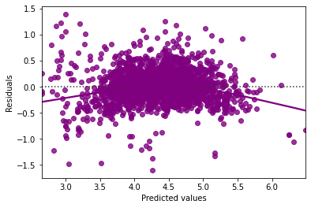

```python
sns.residplot(x=df_pred['Predicted values'], y=df_pred['Residuals'], color='purple', lowess=True);
plt.show()
```

We do not find any pattern in the plot Fitted values vs Residuals.

1. Checking for normality

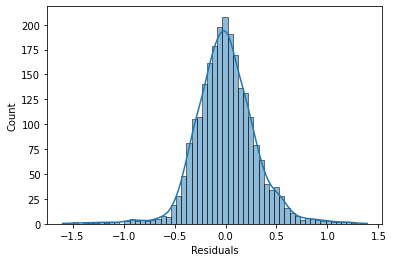

```python
sns.histplot(x=df_pred['Residuals'], kde=True);
plt.show()
```

Plotting the residuals gives a bell shaped curve, we can say the residuals are normally distributed.

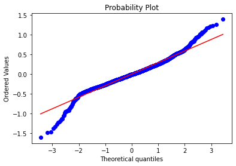

```python
import pylab
import scipy.stats as stats

stats.probplot(df_pred['Residuals'], dist='norm', plot=pylab);
```

From the Q-Q plot, we see that most of the points are lying on the straight line.

```python
stats.shapiro(df_pred['Residuals'])
```

```
ShapiroResult(statistic=0.9672365188598633, pvalue=4.8858485128985114e-23)
```

From the Shapiro-Wilk's test, we check the p-value for normality.

Null hypothesis : Data is normally distributed.

Alternate hypothesis : Data is not normally distributed.

We see that the p-value is very low, which implies the residuals are not normally distributed.

However, as an approximation, we say the distribution is close to being normal.

1. Checking for homoscedasticity

Null hypothesis : Residuals are homoscedastic

Alternate hypothesis : Residuals have hetroscedasticity

```python
from statsmodels.compat.python import lzip
import statsmodels.stats.api as sms
from statsmodels.compat import zip

name=['F-statistic', 'p-value']
test = sms.het_goldfeldquandt(df_pred['Residuals'], X_train)
lzip(name, test)
```

```
[('F-statistic', 0.8624266803458237), ('p-value', 0.9947044377441784)]
```

Since p-value is high, we fail to reject null hypothesis. Residuals are homoscedastic.

## Model Performance Check

```python
X_train.columns #checking columns in training data
```

```
Index(['const', 'screen_size', 'main_camera_mp', 'selfie_camera_mp',
       'int_memory', 'ram', 'battery', 'years_since_release', '4g_yes',
       '5g_yes', 'os_Others', 'os_Windows', 'os_iOS', 'price_range_low'],
      dtype='object')
```

```python
X_test.columns #checking columns in test data
```

```
Index(['const', 'screen_size', 'main_camera_mp', 'selfie_camera_mp',
       'int_memory', 'ram', 'battery', 'weight', 'days_used',
       'years_since_release', '4g_yes', '5g_yes', 'os_Others', 'os_Windows',
       'os_iOS', 'price_range_low', 'price_range_medium'],
      dtype='object')
```

```python
#dropping columns in test data that are not part of training data
X_test2 = X_test.drop(['weight', 'days_used', 'price_range_medium'], axis=1)
```

## Final Model

```python
X_train_final = X_train.copy()
X_test_final = X_test2.copy()
```

```python
olsmod_final = sm.OLS(y_train, X_train_final)
olsres_final = olsmod_final.fit()
print(olsres_final.summary())
```

```
                              OLS Regression Results
=================================================================================
Dep. Variable:     normalized_used_price   R-squared:                       0.742
Model:                               OLS   Adj. R-squared:                  0.740
Method:                    Least Squares   F-statistic:                     531.0
Date:                   Fri, 05 Aug 2022   Prob (F-statistic):               0.00
Time:                           22:15:51   Log-Likelihood:                -491.86
No. Observations:                   2417   AIC:                             1012.
Df Residuals:                       2403   BIC:                             1093.
Df Model:                             13
Covariance Type:               nonrobust
=======================================================================================
                          coef    std err          t      P>|t|      [0.025      0.975]
---------------------------------------------------------------------------------------
const                   2.4317      0.050     48.424      0.000       2.333       2.530
screen_size             0.0586      0.003     20.197      0.000       0.053       0.064
main_camera_mp          0.0356      0.002     22.240      0.000       0.032       0.039
selfie_camera_mp        0.0213      0.001     15.273      0.000       0.019       0.024
int_memory              0.0004   7.78e-05      4.723      0.000       0.000       0.001
ram                     0.0769      0.006     11.952      0.000       0.064       0.090
battery              2.496e-05   8.81e-06      2.833      0.005    7.68e-06    4.22e-05
years_since_release     0.0258      0.004      5.964      0.000       0.017       0.034
4g_yes                  0.1794      0.019      9.525      0.000       0.142       0.216
5g_yes                  0.1139      0.040      2.817      0.005       0.035       0.193
os_Others              -0.0508      0.036     -1.404      0.161      -0.122       0.020
os_Windows              0.0841      0.044      1.930      0.054      -0.001       0.169
os_iOS                  0.3460      0.057      6.042      0.000       0.234       0.458
price_range_low        -0.0962      0.019     -5.157      0.000      -0.133      -0.060
==============================================================================
Omnibus:                      164.983   Durbin-Watson:                   1.948
Prob(Omnibus):                  0.000   Jarque-Bera (JB):              799.256
Skew:                           0.008   Prob(JB):                    2.78e-174
Kurtosis:                       5.817   Cond. No.                     3.24e+04
==============================================================================

Warnings:
[1] Standard Errors assume that the covariance matrix of the errors is correctly specified.
[2] The condition number is large, 3.24e+04. This might indicate that there are
strong multicollinearity or other numerical problems.
```

Exploring the results

```python
y_pred = olsres_final.predict(X_test_final)
```

Evaluating metrics for regression

- Checking the mean absolute errors and root mean square errors for training dataset

```python
training_mae = mean_absolute_error(y_train, df_pred['Predicted values'])
print("MAE in training set : ", training_mae)
training_mse = mean_squared_error(y_train, df_pred['Predicted values'])
print("MSE in training set : ", training_mse)
training_rmse = np.sqrt(mean_squared_error(y_train, df_pred['Predicted values']))
print("RMSE in training set : ", training_rmse)
```

```
MAE in training set :  0.21848052899757628
MSE in training set :  0.08795976139418206
RMSE in training set :  0.29658010957274605
```

- Checking the mean absolute errors and root mean square errors for testing dataset

```python
testing_mae = mean_absolute_error(y_test, y_pred)
print("MAE in testing set : ", testing_mae)
testing_mse = mean_squared_error(y_test, y_pred)
print("MSE in testing set : ", testing_mse)
testing_rmse = np.sqrt(mean_squared_error(y_test, y_pred))
print("RMSE in testing set : ", testing_rmse)
```

```
MAE in testing set :  0.22110304278112206
MSE in testing set :  0.08624871452535739
RMSE in testing set :  0.2936813145662444
```

```python
df_pred_test = pd.DataFrame()
df_pred_test['Actual value'] = y_test
df_pred_test['Predicted value'] = y_pred
df_pred_test['Residual'] = y_test - y_pred
df_pred_test.sample(10, random_state=1)
```

|  | Actual value | Predicted value | Residual |
| --- | --- | --- | --- |
| 1995 | 4.705197 | 4.442073 | 0.263124 |
| 2341 | 3.966132 | 4.240372 | -0.274239 |
| 1913 | 3.536602 | 3.797031 | -0.260429 |
| 688 | 4.382901 | 4.555387 | -0.172485 |
| 650 | 4.175771 | 4.415479 | -0.239708 |
| 2291 | 4.653675 | 4.466572 | 0.187103 |
| 40 | 4.539991 | 4.743564 | -0.203573 |
| 1884 | 4.754280 | 4.493650 | 0.260629 |
| 2538 | 4.944068 | 4.650742 | 0.293326 |
| 45 | 4.789822 | 4.767254 | 0.022569 |

- The model is able to explain ~74% of the variation in the data.
- The train and test RMSE and MAE are low and comparable. This implies our model is not suffering from overfitting.
- Hence, we can conclude the model *olsmod_final* is good for prediction as well as inference purposes.

Automating the equation of fit

```python
olsres_final.params
```

```
const                  2.431723
screen_size            0.058611
main_camera_mp         0.035622
selfie_camera_mp       0.021279
int_memory             0.000367
ram                    0.076889
battery                0.000025
years_since_release    0.025811
4g_yes                 0.179357
5g_yes                 0.113907
os_Others             -0.050771
os_Windows             0.084056
os_iOS                 0.346004
price_range_low       -0.096157
dtype: float64
```

```python
equation = 'normalized_used_price = '
print(equation , end=" ")
for i in range(1, len(X_train_final.columns)):
  print(round(olsres_final.params[i],7),
            "* (",
            X_train_final.columns[i],
            ")" + " + ", end = " ")
print(round(olsres_final.params[0],7))
```

[output not shown]

## Actionable Insights and Recommendations

- The model is able to explain ~74% of the variations in `normalized_used_price`, with an MAE of 22.11% on test data. Hence, we can say the model is good for prediction as well as inferential purposes.
- For a unit increase in most of the features, the `normalized_used_price` increases.
- However, certain features create more impact than others, and we have consolidated the findings below.
  1. Increasing `screen_size` by one unit increases `normalized_used_price` by 0.058611 units, keeping all other variables constant.
  2. If the `ram` increases by one unit, the `normalized_used_price` increases by 0.076889 units, keeping all other variables constant.
  3. As expected, the `normalized_used_price` increases by 0.346004 units for devices running on iOS, keeping all other variables constant.
  4. The `normalized_used_price` decreases by 0.050771 units for devices running on OS other than iOS, Windows or Android, keeping all other variables constant.
  5. For devices supporting 4g, the `normalized_used_price` increases by 0.179357 units, keeping all other variables constant.
  6. For devices supporting 5g, the `normalized_used_price` increases by 0.113907 units, keeping all other variables constant.
- The `normalized_used_price` for devices categorized under low price range decreases by 0.096157 units, keeping all other variables constant.
- ReCell can focus more on the above mentioned data for better profits.